# Template for Assignment

12/09/2021

## Assignment 2

### Information and tips in Rmarkdown

We can set different heading sizes by the number of hashtags infront

## Heading 2

### Heading 3

We can also include code in an rmarkdown but not have it run i.e. for `install.packages()` as we only need to install once and not again. This is done by include `eval=FALSE` in the rchunk- See install.packages() in chunk below.

### Introduction

Note: If presenting data look at DT package (Week 9 lecture notes)

```r
install.packages("RCurl")
install.package("ggplot2")
instal.package("data.table")
```

```r
library(RCurl)
```

```r
url_content = getURL("https://data.nsw.gov.au/data/dataset/97ea2424-abaf-4f3e-a9f2-b5c883f42b6a/resource/2776dbb8-f807-4fb2-b1ed-184a6fc2c8aa/download/confirmed_cases_table4_location_likely_source.csv")
covidnsw = read.csv(textConnection(url_content), header=T)
```

### Analysis

```r
library(dplyr)
covid_bylhd=covidnsw %>%
  count(lhd_2010_name)
```

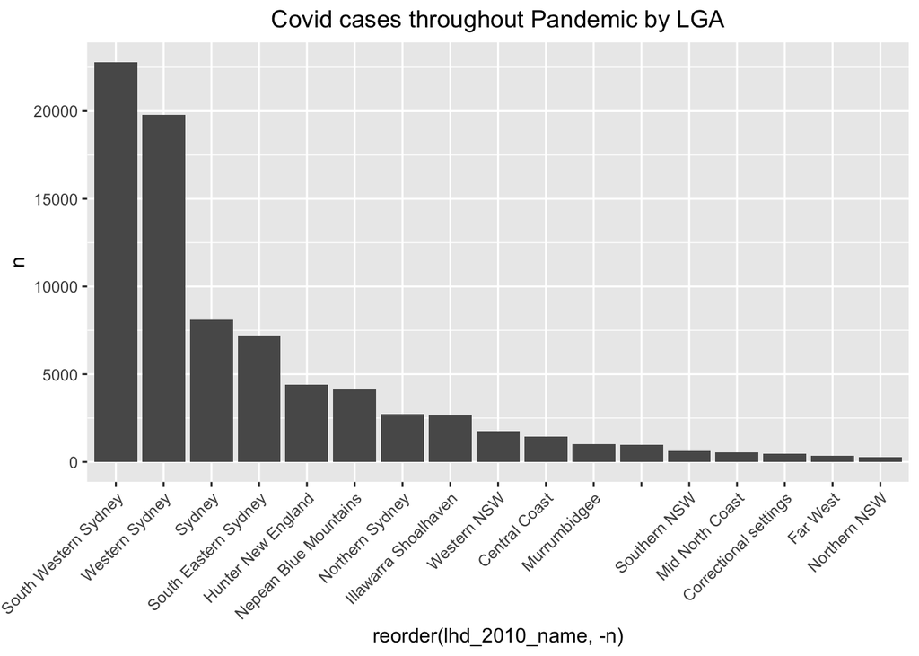

```r
library(ggplot2)
ggplot(covid_bylhd, aes(reorder(lhd_2010_name,-n), n)) +
  geom_bar(stat="identity") +
  theme(axis.text.x = element_text(angle = 45, vjust = 1, hjust=1))+
  ggtitle("Covid cases throughout Pandemic by LGA") +
  theme(plot.title = element_text(hjust = 0.5))
```

### Shiny Application

Include the shiny application here for the data variable you are looking at including or describing. Let say an interactive plot for cases in LGA in Hunter new England Area in latest outbreak. Firstly save as data table (allow searchability and reduction) extract that data you are after.

```r
library(data.table)
covidnsw=as.data.table(covidnsw)
covidnswhne_local_2= covidnsw[(as.character(notification_date) >="2021-07-10") & !(likely_source_of_infection %in% "Overseas") & (lhd_2010_name %in% "Hunter New England")]  #remove Oversea cases only and latest outbreak and from HNE area

covid1=covidnswhne_local_2 %>%
  count(notification_date, lga_name19)    #Covid cases in each LGA and number each data

covid1$notification_date=as.Date(covid1$notification_date)  #Make sure the variable is a date format
```

NOTE: To make these interactive, download this rmarkdown file on your computer and run all above chucks, and then run each of the chuck below one at a time which will open the shiny object. The submitted assignment in html format wont run these shiny objects in an interactive way- this requires the object to be published and have a url link (not covered or required in course). This is why the rmarkdown document will be required for marking.

I will include two different way to present the same plot-

```r
library(shiny)
library(ggplot2)

ui <- fluidPage(
  titlePanel("Dashboard"),

  sidebarLayout(
    sidebarPanel(
      selectInput(inputId = "quintile", label = ("LGA Within Hunter New England Health"),
                  choices = unique(covid1$lga_name19)
      )),




    mainPanel(
      plotOutput(outputId = "plot")
    )
  )
)


# Define server logic required to draw a histogram
server <- function(input, output) {
  filtered_data<- reactive({
    test <- covid1[covid1$lga_name19 %in% input$quintile]

     })
  output$plot <- renderPlot({ggplot(filtered_data(), aes(x = notification_date, y = n)) +
    geom_line(aes(colour=lga_name19, group=lga_name19)) +
    theme(axis.text.x = element_text(angle = 45, vjust = 1, hjust=1)) +
    ggtitle("Covid cases in HNE by LGA") +
    theme(plot.title = element_text(hjust = 0.5))},height = 400,width = 600)}


shinyApp(ui = ui, server = server)
```

Shiny applications not supported in static R Markdown documents

This second option allows multiple LGA within HNE to be selected.

```r
library(shiny)
library(ggplot2)

ui <- fluidPage(
    sidebarLayout(sidebarPanel(selectInput(inputId = "quintile", label = ("LGA Within Hunter New England Health"),choices = unique(covid1$lga_name19), multiple = TRUE, selected=as.factor(as.character(covid1$lga_name19))[1])),
                               mainPanel(plotOutput(outputId = "plot")
    )))



# Define server logic required to draw a histogram
server <- function(input, output) {
  filtered_data<- reactive({
    test <- covid1[covid1$lga_name19 %in% input$quintile]

     })
  output$plot <- renderPlot({ggplot(filtered_data(), aes(x = notification_date, y = n)) +
    geom_line(aes(colour=lga_name19, group=lga_name19)) +
    theme(axis.text.x = element_text(angle = 45, vjust = 1, hjust=1)) +
    ggtitle("Covid cases in HNE by LGA") +
    theme(plot.title = element_text(hjust = 0.5))+  scale_x_date(limits = c(min(as.Date(covid1$notification_date)),max(as.Date(covid1$notification_date))))},height = 400,width = 600)}


shinyApp(ui = ui, server = server)
```

Shiny applications not supported in static R Markdown documents